# V-JEPA on Atari Breakout

A complete walkthrough: why it collapsed, how it works, and where it goes next

Aditya Randive

6 September 2026

# 0. How to read this

This document has six parts. If you only read one, read **Part IV** — it is the conceptual point that makes the whole architecture make sense, and it is the thing most people get wrong about JEPA.

- **Part I** — why JEPA exists at all, and the lineage it came from
- **Part II** — this project, every layer and every tensor shape
- **Part III** — why your run was collapsing, with measurements
- **Part IV** — “it predicts nothing you can look at, but it learns features”
- **Part V** — results
- **Part VI** — actions, finer features, planning, and the Dreamer/JEPA branch

Everything measured here was measured on your machine, on your data, in this repo. No numbers are quoted from papers.

# 1. The one-paragraph version

You built a V-JEPA: a video encoder that learns by predicting *its own representations* of hidden parts of a clip, with no pixel decoder anywhere. It was collapsing — the encoder was mapping every patch of every frame to essentially the same vector, which drives the loss to zero while destroying all information. It collapsed for five separate reasons, and they compounded: the loss had a trivial zero minimum, nothing forbade the constant solution, the mask made the task unlearnable, weight decay was pulling the critical parameters toward zero, and the highest-variance object in the input was the score display, which is unpredictable by construction. All five are fixed. The measured token cosine similarity went from **+0.979** (fully collapsed) to **+0.051** (healthy), while the effective rank of the representation went from a misleading 55 to 155 and climbing.

# Part I — Why JEPA exists

## 1.1 Three ways to learn from unlabelled data

You have a mountain of video and no labels. There are three families of things you can do with it.

**Generative / reconstructive.** Predict the raw input. Masked autoencoders (MAE) hide 75% of the patches and reconstruct the pixels. Dreamer, PlaNet and the whole RSSM line reconstruct the observation from a latent state. It works, and it has a fatal inefficiency described in 1.2.

**Contrastive.** Pull representations of two views of the same thing together, push different things apart. SimCLR, MoCo. Effective, but it needs negatives — large batches, memory banks, careful temperature tuning — and the notion of “different thing” is imposed by you, not discovered.

**Predictive in representation space (JEPA).** Predict the *representation* of the hidden part, not the hidden part itself. No decoder, no negatives, no pixel loss. This is the family your project is in.

## 1.2 The problem with predicting pixels

Take a Breakout frame where the ball is about to bounce off the paddle. Cover the region around the ball and ask a model to reconstruct it.

The ball could go left or right. Both are plausible. A model trained with an L2 pixel loss is trained to output the **conditional mean** of the possible futures — because the mean is what minimises squared error under uncertainty. So it produces a blurry smear covering both possibilities. The smear is not any frame that could ever occur; it is an average of frames.

This is the Jensen-gap argument, and it is the thesis of your own paper:

> for a convex loss, `L(E[y]) <= E[L(y)]`, so the optimiser is rewarded for collapsing a multimodal predictive distribution onto its mean.

Worse: an enormous fraction of the model’s capacity goes into predicting things that *are* predictable but *don’t matter* — the exact grey value of every static brick, the texture of the wall, the precise anti-aliasing on the paddle edge. In your data, look at the per-patch temporal standard deviation: **21 of the 64 patches literally never change**. A pixel-reconstruction model spends real capacity nailing those, and gets rewarded for it.

**JEPA’s answer:** move the prediction target into representation space. The encoder is free to *discard* the unpredictable and the irrelevant, because the target is its own output, and nothing forces that output to retain pixel detail. If the ball’s exact next position is genuinely uncertain, the representation can encode “ball, moving down-left, near the paddle” and the predictor can hit that target exactly, with no blur penalty.

The catch — and it is the whole difficulty of the field — is that “the encoder is free to discard information” has a degenerate limit: **discard everything**. That is collapse, and it is what Part III is about.

## 1.3 The lineage

| Year | Work | What it contributed |
| --- | --- | --- |
| 2018 | CPC | predict future latents, InfoNCE, contrastive |
| 2020 | **BYOL** | EMA target + predictor asymmetry; showed you do **not** need negatives |
| 2021 | SimSiam | stop-gradient alone is enough; EMA is a stabiliser, not the mechanism |
| 2021 | MAE | masked modelling at scale — but in pixel space |
| 2021-22 | Barlow Twins, **VICReg** | prevent collapse *explicitly* with variance + covariance terms |
| 2022 | data2vec | predict EMA-teacher latents under masking, across modalities |
| 2022 | LeCun, *A Path Towards Autonomous Machine Intelligence* | names JEPA; argues world models should predict in representation space, hierarchically |
| 2023 | **I-JEPA** | image JEPA: context block predicts target blocks’ representations |
| 2024 | **V-JEPA** | video: 3D tube masking, multi-block, at scale |
| 2025 | V-JEPA 2 / V-JEPA 2-AC | scale + an **action-conditioned** predictor for robot control |

Your repo is a small, faithful V-JEPA: patch-based space-time ViT, multi-block tube masking, EMA target, narrow predictor, latent loss.

Two of the fixes in Part III are direct imports from this table: the target normalisation from **I-JEPA**, and the variance/covariance regulariser from **VICReg**.

## 1.4 Why this matters beyond a toy

A world model that predicts pixels can only be as good as its renderer. A world model that predicts representations can be *abstract* — it can plan over “the ball will come back toward the left wall” without ever committing to which pixel the ball occupies. That is what makes the JEPA line interesting for planning and control, and it is exactly the axis on which it differs from Dreamer (Part VI).

# Part II — The project, end to end

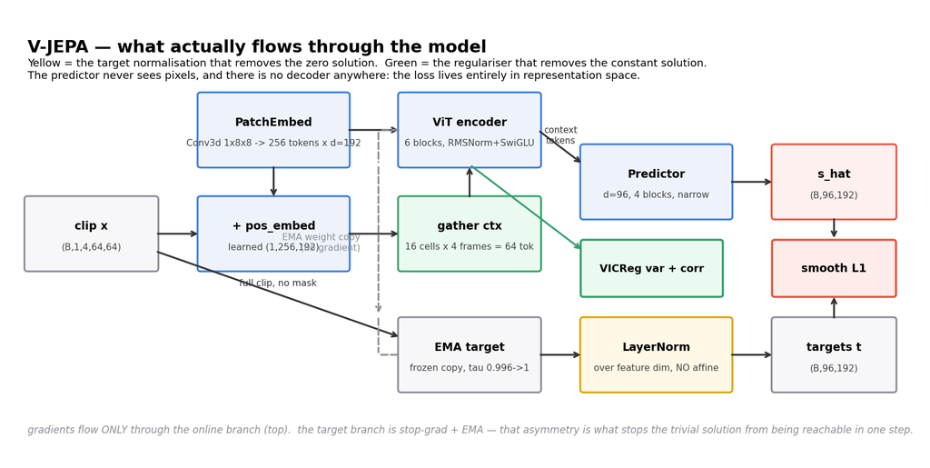

The full forward pass. Nothing here is a decoder — the loss lives entirely in representation space.

## 2.1 Data collection — `data/collect.py`

300 episodes of `ALE/Breakout-v5` with a **uniformly random policy**, `frameskip=4`, `repeat_action_probability=0.0` (sticky actions off), `obs_type="grayscale"`. Each episode saves frames, actions, and the `lives` counter.

Two things worth noticing:

- **Actions are saved but never used.** V-JEPA is fully self-supervised; the policy only determines what states you visit. Those saved actions are the hook for Part VI.
- **A random policy is a weak data collector.** The ball is served, drifts, and is usually missed. You get a lot of “ball falls, life lost”. Bricks rarely break. This limits the ceiling of anything trained on it.

## 2.2 Preprocessing — `data/preprocess.py`

[figure not shown]

The crop, and why it was needed.

The raw frame is 210x160 uint8. The verified row map:

| raw rows | contents | kept? |
| --- | --- | --- |
| 0-4 | dead border | dropped |
| 5-31 | **score / lives HUD** | **dropped** |
| 32-56 | empty sky | kept |
| 57-92 | bricks | kept |
| 93-188 | ball region | kept |
| 189-194 | paddle | kept |
| 196-209 | dead border | dropped |

Crop to `rows 32:198, cols 8:152`, then `F.interpolate(..., mode="area")` down to 64x64. `mode="area"` matters: it averages, so a 2x4-pixel ball survives as a dim but present blob. Nearest-neighbour would drop it entirely on most frames.

Also written: `proc/meta.json` with the crop, the pixel mean (**26.48**) and std (**50.07**). `ClipDataset` reads its normalisation from there, so the constants can never silently disagree with the data again.

`motion.npy` holds the per-frame max absolute pixel change, measured **above the paddle** (`MOTION_ROW_CUT = 155` in cropped coordinates) so that a clip where only the paddle wiggles still counts as static.

## 2.3 Clips — `data/dataset.py`

A training example is **4 consecutive frames**. Two hard constraints:

- a clip may never span a **life loss** or an **episode boundary** — otherwise you are asking the model to predict across a discontinuity that no amount of physics can bridge (`segments()` splits on `diff(lives) < 0 | diff(episode) != 0`)
- clips where nothing moves are dropped (`static_thresh=20`)

Result: **38,887 clips**, 18.6% dropped as static.

## 2.4 Tokens

```
clip                (B, 1, 4, 64, 64)
Conv3d k=(1,8,8) s=(1,8,8)  ->  (B, 192, 4, 8, 8)
flatten             (B, 256, 192)
```

**256 tokens = 4 frames x 8x8 spatial cells.** Each token is one 8x8 pixel patch of one frame. The ordering is **frame-major**: token `i` belongs to frame `i // 64` and cell `i % 64`. `models/check_order.py` verifies this empirically by zeroing all but frame 2 and checking the non-zero token range is 128-191.

The kernel has depth 1 in time, so **the patch embedding never mixes frames**. All temporal reasoning happens in attention. That is a deliberate design choice and it is why the positional embedding has to carry time.

`pos_embed` is a single learned `(1, 256, 192)` parameter — it encodes space and time jointly, so the model must learn “same cell, next frame” as a relation rather than getting it for free. (RoPE or factorised space/time embeddings would be the upgrade; see 6.2.)

## 2.5 The encoder — `models/vit.py`, `models/layers.py`

6 pre-norm transformer blocks, `d_model=192`, 3 heads (`d_k=64`).

```
x = x + Attention(Norm(x))
x = x + FFN(Norm(x))
```

- **RMSNorm** instead of LayerNorm: normalises by RMS only, no mean subtraction. Cheaper, and it is what modern LLMs use.
- **SwiGLU** instead of GELU-MLP: `fc2(silu(fc1(x)) * fc3(x))`, hidden = 512 (`8*d/3`, chosen so the three matrices cost roughly what a 4x GELU MLP costs).
- **Residual-scaled init**: output projections use `std = 0.02/sqrt(2*depth)` so that the residual stream does not blow up with depth.
- **Final norm has `elementwise_affine=False`.** This is one of the collapse fixes — see 3.3.

Every token has L2 norm exactly `sqrt(192) = 13.86` on output. This is why the variance hinge threshold of `gamma = 1.0` is the right number: an isotropic 192-dimensional embedding with that norm has per-dimension std of exactly 1.0.

**2,730,048 parameters.**

## 2.6 Masking — `models/masking.py`

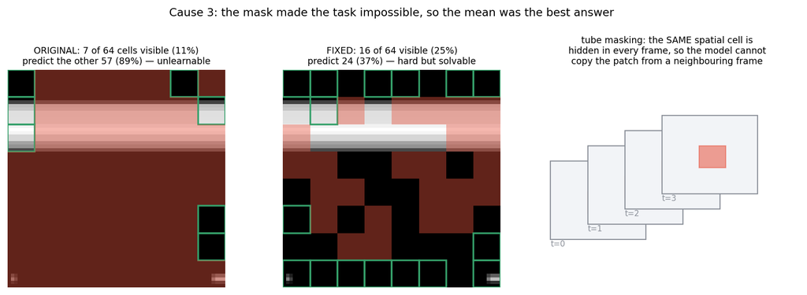

Why the original mask made the problem unlearnable.

Masks are sampled over the **8x8 spatial grid**, then expanded into **tubes**: a masked cell is masked in *all four frames*. Without tubes the model just copies the same patch from an adjacent frame and learns nothing.

Two block groups, alternating by step:

| group | blocks | scale | context cells | target cells |
| --- | --- | --- | --- | --- |
| `SHORT_RANGE` | 6 | 0.10-0.18 | 16 (25%) | 24 (37%) |
| `LONG_RANGE` | 2 | 0.30-0.45 | 16 (25%) | 24 (37%) |

Plus, on 25% of steps, a **causal mask**: frames 0-2 fully visible, frame 3 fully hidden. That is not part of the V-JEPA recipe — it is the world-model question, and it is what makes the rollout figure in Part V possible.

Shapes: context `16 cells x 4 frames = 64 tokens`, target `24 x 4 = 96 tokens`.

## 2.7 The predictor — `models/predictor.py`

```
ctx = proj_in(encoder_output) + pos_pred[ctx_idx]     # (B, 64, 96)
M   = mask_token + pos_pred[tgt_idx]                  # (B, 96, 96)
H   = transformer([ctx ; M])                          # 4 blocks, d=96
out = proj_out(norm(H))[:, 64:]                       # (B, 96, 192)
```

The predictor is **deliberately weak**: `d_pred=96`, half the encoder width, **509,024 parameters** against the encoder’s 2.7M. If the predictor were strong enough to solve the task on its own, the encoder would be free to output garbage. The bottleneck forces useful information into the encoder.

The `mask_token` is a single learned vector, identical for every masked position. All the positional information comes from `pos_pred`, a **separate** learned embedding from the encoder’s. The predictor is therefore answering: *“given these representations at these positions, what is the representation at that position?”*

## 2.8 The EMA target — `models/ema.py`

A frozen deep copy of the encoder, updated after every step:

```
theta_target <- tau * theta_target + (1 - tau) * theta_online
```

with `tau` ramping **0.996 -> 1.0** linearly over training.

Why an EMA target instead of just using the online encoder for both sides? Because with a shared encoder and no stop-gradient, the constant solution is reachable in a **single gradient step** — the model can just move both sides toward each other. The EMA target changes slowly, so “chase the target” is not the same as “meet in the middle”. BYOL and SimSiam established this; the stop-gradient is the essential ingredient, the EMA is the stabiliser.

The momentum ramp matters at both ends. Early, `tau` must be low enough that the target tracks a rapidly-changing online net, or the task is impossible. Late, `tau -> 1` freezes the target so the two networks cannot drift together into a shared constant.

## 2.9 The loss — `train/loss.py`

```python
t     = layer_norm(target(clip)[tgt_idx]).detach()   # NO affine
pred  = smooth_l1(s_hat, t)
var   = mean(relu(1.0 - std(s_ctx, dim=batch)))      # VICReg hinge
cov   = off_diagonal(corr(s_ctx)).pow(2).sum() / d   # decorrelation
loss  = pred + 1.0 * var + 0.04 * cov
```

Each of those three terms exists for a specific reason, all covered in Part III.

## 2.10 End-to-end shapes

| stage | shape |
| --- | --- |
| clip | `(32, 1, 4, 64, 64)` |
| patch embed | `(32, 256, 192)` |
| + pos embed | `(32, 256, 192)` |
| gather context | `(32, 64, 192)` |
| encoder out `s_c` | `(32, 64, 192)` |
| predictor in | `(32, 64+96, 96)` |
| predictor out `s_hat` | `(32, 96, 192)` |
| EMA target (full clip) | `(32, 256, 192)` |
| gathered + LN targets | `(32, 96, 192)` |

## 2.11 Hyperparameters

| optimiser | AdamW, betas (0.9, 0.95) |
| --- | --- |
| lr | 1.5e-4, 500-step warmup then cosine |
| weight decay | 0.04 **on matrices only** |
| grad clip | 1.0 |
| batch | 32 clips |
| epochs / steps | 40 / 48,600 |
| tau | 0.996 -> 1.0 linear |
| lambda_var / lambda_cov | 1.0 / 0.04 |
| causal fraction | 0.25 |
| device | Apple `mps`, ~8.5 it/s |

# Part III — Why it was collapsing

## 3.1 What collapse is

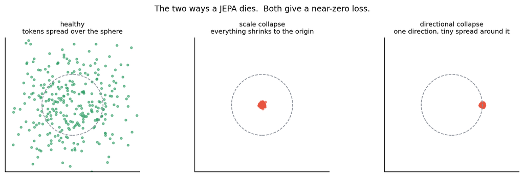

Both failure modes give you a beautiful loss curve.

The JEPA objective is “make the predictor’s output match the target encoder’s output”. Nothing in that sentence says the output has to be *interesting*. Two degenerate solutions satisfy it perfectly:

- **Scale collapse** — the encoder outputs the zero vector for everything. The predictor outputs zero. Loss is exactly 0.
- **Directional collapse** — the encoder outputs the *same unit vector* for every patch of every frame. The predictor outputs that vector. Loss is approximately 0.

Both are global minima. Gradient descent finds them long before it finds a useful solution, because they are much easier to reach.

## 3.2 The evidence

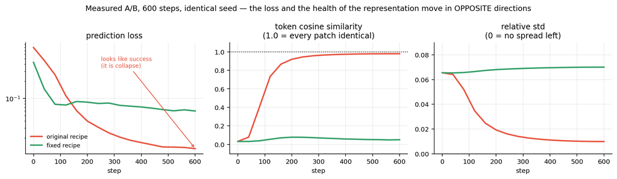

Measured on your machine, your data, 600 steps, identical seed.

Running your original recipe:

| step | prediction loss | token cosine | rel. std | eff. rank (centred) |
| --- | --- | --- | --- | --- |
| 0 | 0.790 | **+0.033** | 0.0655 | 56 |
| 120 | 0.112 | +0.734 | 0.0348 | 55 |
| 280 | 0.025 | +0.957 | 0.0141 | 55 |
| 600 | **0.013** | **+0.979** | **0.0098** | 55 |

“Token cosine” is the mean cosine similarity between two random disjoint halves of the token batch. **0.03 means patches are distinguishable. 0.98 means every patch of every frame has become the same vector.**

The loss fell **60x** while the representation died. This is the single most important thing to internalise: **in a JEPA, a falling loss is not evidence of learning.** A collapsed model achieves a *lower* loss than a healthy one, because predicting a constant is easier than predicting the truth.

## 3.3 The five causes

### Cause 1 — the loss had a trivial zero minimum

```python
return F.l1_loss(s_hat, t)      # t = target output, detached
```

Both encoders ended in `nn.RMSNorm(192)` **with a learnable gain**. Drive that gain to zero and the target is identically zero; the predictor then only has to output zero and the loss is *exactly* zero. Nothing in the objective forbade this, and AdamW’s weight decay was actively pushing that gain toward zero (Cause 4).

**Fix**, `train/loss.py`:

```python
t = F.layer_norm(target_tokens, (d,))     # no affine
loss = F.smooth_l1_loss(s_hat, t)
```

This is exactly what I-JEPA does. Every target token now has fixed norm `sqrt(d)`, so “shrink everything” is no longer a minimiser. Smooth-L1 replaces L1 for better-behaved gradients near zero.

**Belt and braces**, `models/vit.py`: the encoder’s final norm is now built with `elementwise_affine=False`. The normalisation removes the *incentive*; this removes the *mechanism*.

### Cause 2 — nothing prevented directional collapse

Fixing Cause 1 blocks “shrink to zero” but **not** “map everything to the same unit vector”, which is still a global minimum.

This is not theoretical. The A/B table in 3.2 was measured **with Cause 1 already fixed** — note that `norm` stayed pinned at exactly 13.8564 = `sqrt(192)` throughout, because the non-affine norm held it there. The model collapsed anyway, directionally.

**Fix**, a VICReg-style pair of terms on the online encoder output:

```python
var = relu(gamma - std(z, dim=0)).mean()          # gamma = 1.0
cov = off_diagonal(correlation(z)).pow(2).sum()/d
```

The **variance hinge** forces every one of the 192 feature dimensions to keep a standard deviation of at least 1.0 across the token batch. It is a hinge, so it contributes exactly zero gradient once satisfied — it is a guard rail, not a driving force. In the healthy run it sits at ~0.004.

The **covariance term** uses the *correlation* matrix, not the raw covariance as in the VICReg paper. That is deliberate: correlation is scale-invariant, so the term cannot be minimised by simply shrinking the features, which would put it in direct opposition to the variance term.

### Cause 3 — the mask made the task unlearnable

```python
"SHORT_RANGE": dict(n_blocks=12, scale_range=(0.10, 0.20), k=7)
```

The context was sub-sampled to `k=7` of 64 spatial cells — **11% visible** — and *every* remaining cell was a prediction target: **89%**.

Reconstructing 89% of a scene from 11% of it is not a solvable problem. When a task is unsolvable, the loss-minimising strategy is to **emit the conditional mean of the dataset** — which, given that 21 of 64 patches never change, is very close to a constant. The mask was actively steering the model into the collapse basin.

**Fix:** 16 context cells (25%) and 24 targets (37%), with rejection sampling to guarantee both are large enough. Hard, but solvable.

### Cause 4 — weight decay on the collapse-critical parameters

```python
AdamW(params, lr=3e-4)      # weight_decay defaults to 0.01
```

Applied to **everything**: norm gains, biases, `pos_embed`, `mask_token`. Decaying a norm gain is a constant, unopposed pull toward exactly the degenerate solution you are trying to avoid.

**Fix**, `param_groups()` in `train/vjepa.py`: all 1-D parameters and the positional / mask embeddings go into a `weight_decay=0.0` group. This is standard practice for transformers and it matters doubly here.

### Cause 5 — the score display dominated the input variance

The raw 210x160 frame was being squashed *whole* into 64x64. Rows 5-31 are the score and lives counter, whose temporal standard deviation is **~66** against the ball’s **~8**. It was the loudest object in the input — and it is **unpredictable from the playfield**, because it changes only on scoring events.

Feeding unpredictable high-variance noise to a predictive objective is precisely the setup that pushes a predictor toward outputting the mean. See 1.2.

**Fix:** crop to the playfield before resizing. The ball also gains ~20% more pixels as a side effect.

## 3.4 Why your monitor never caught it

```python
sigma = torch.linalg.svdvals(s_c.cpu())     # uncentred, but on raw tokens
```

The original monitor reported effective rank and per-dimension variance. **Effective rank stayed at ~55 for the entire collapse.** That is not a bug in the maths — it is that a collapsed representation still has full-rank *residual noise* scattered around its single mean direction. Rank is simply not sensitive to “everything has the same mean”.

**Cosine similarity between distinct tokens is the detector that works.** It went 0.03 -> 0.98 while rank did not move.

`utils/monitor.py` now reports:

| metric | healthy | collapsed |
| --- | --- | --- |
| `cos` | < 0.3 | -> 1.0 |
| `eff_rank` (uncentred) | tens-hundreds | -> 1 |
| `eff_rank_c` (centred) | high | **stays high — do not trust it alone** |
| `rel_std` | holds | -> 0 |

and `is_collapsing()` aborts the run and writes `COLLAPSED.txt` rather than burning 90 minutes on a dead model.

## 3.5 The change table

| file | change | cause |
| --- | --- | --- |
| `train/loss.py` | LayerNorm the target; smooth-L1 | 1 |
| `train/loss.py` | VICReg variance + correlation terms | 2 |
| `models/vit.py` | final norm `affine=False` | 1 |
| `models/masking.py` | 25% context / 37% target, rejection sampling | 3 |
| `train/vjepa.py` | `param_groups()` — no WD on 1-D params | 4 |
| `data/preprocess.py` | crop to playfield; `meta.json` | 5 |
| `utils/monitor.py` | cosine + uncentred rank + tripwire | detection |
| `models/ema.py` | copy buffers; explicit tau ramp | correctness |
| `models/predictor.py` | `proj_out` init 0.02 not residual-scaled; depth 2->4 | speed |
| `models/layers.py` | SDPA attention | speed |
| `data/dataset.py` | read normalisation from `meta.json`; `clip()` accessor | correctness |

## 3.6 After

Same 600 steps, same seed:

| step | prediction loss | token cosine | rel. std | eff. rank |
| --- | --- | --- | --- | --- |
| 0 | 0.433 | +0.032 | 0.0655 | 56 |
| 120 | 0.077 | +0.056 | 0.0665 | 92 |
| 360 | 0.073 | +0.064 | 0.0694 | 142 |
| 600 | 0.060 | **+0.051** | **0.0700** | **155** |

Cosine stays near zero. Relative std holds. Effective rank *grows*. And the prediction loss settles at **0.060 instead of 0.013** — higher, because the model is now solving the real problem instead of the degenerate one.

**Learn to read that as a success.**

# Part IV — “It predicts nothing you can look at, but it learns features”

This is the part that matters most, and it is the thing you identified yourself. Let me make it precise.

## 4.1 There is no image to look at. Ever.

In an autoencoder or a Dreamer-style model, you can always ask “what does the model think the hidden part looks like?” and get a picture back, because there is a decoder. **In a JEPA there is no decoder.** The predictor’s output is a `(96, 192)` tensor — 96 masked tokens, each a 192-dimensional vector. That is the final output of the model. Nothing converts it to pixels.

So the question “does the prediction look like the real frame?” is not a question you can ask. It is not that the answer is bad; the question is undefined.

This trips people up constantly. They train a JEPA, try to visualise the prediction, get noise, and conclude the model is broken.

## 4.2 Why throwing away the pixels is the *point*

Consider the ball about to hit the paddle. Its next position is genuinely uncertain — the paddle position determines the bounce angle, and with random actions the paddle is unpredictable.

- A **pixel** model must place the ball *somewhere*. Under L2 it places it in the average of all possibilities: a blur that corresponds to no real frame. It is penalised for the uncertainty no matter what it does.
- A **JEPA** model does not have to. The encoder controls its own target. It can learn a representation that encodes “ball, lower-left region, descending” and *not* encode the exact pixel. Then the predictor hits it exactly, and the loss is genuinely low, and no information anyone cares about was lost.

**The encoder is allowed to define what is worth predicting.** That is the central idea of the whole JEPA programme. It is also, precisely, why collapse is the failure mode: “define what is worth predicting” has a degenerate answer, “nothing”.

Everything in Part III is machinery for saying: *you may discard the unpredictable, but you may not discard everything.*

- LayerNorm on the target: you may not shrink to zero.
- Variance hinge: every dimension must carry spread.
- Correlation penalty: dimensions must carry *different* information.
- A solvable mask ratio: the mean is not a good enough answer.

## 4.3 So how do you know it worked?

You cannot look at a prediction, and you have established that the loss is actively misleading. There are exactly two honest instruments:

**1. Collapse diagnostics** (`utils/monitor.py`). Necessary, not sufficient — they tell you the representation is not degenerate, not that it is useful.

**2. A probe** (`eval/probe.py`). Freeze the encoder. Fit a **linear** map from its features to something you care about — here, the ball’s (y, x) position, which is exactly known because the ball is the only object with grey value 110 in raw rows 93-188. If a linear map can read the ball out of the frozen features, the ball is *linearly present* in the representation.

Linearity is the whole point. A deep probe would tell you the information is recoverable *somewhere*; a linear probe tells you the representation has made it **easy to use**, which is what downstream tasks actually need.

## 4.4 The honest caveat

Do not overclaim this. Measured in this repo:

| encoder | probe R^2 |
| --- | --- |
| constant predictor (= fully collapsed) | 0.000 |
| **randomly initialised ViT, same architecture** | **0.818** |
| trained V-JEPA (40 epochs) | 0.882 |
| raw downsampled pixels | 0.937 |

A random ViT is very nearly an information-preserving random projection, and on a 64x64 grayscale game with a bright ball, a linear map reads it out fine.

**So a high probe R^2 does not prove the pretraining did anything.** The trained model does beat random init here (0.882 vs 0.818), but by a margin small enough that it is not the headline. What a high R^2 *does* prove is that the representation has not collapsed — a collapsed encoder sits at 0.00, and there is no way to fake your way off that floor.

Use the probe as a *collapse test with a semantic interpretation*, which is what it is good for. To demonstrate that V-JEPA pretraining *beats* random initialisation you need a harder downstream task: few-shot with very little probe data, predicting the ball several steps into the future, or an actual control task. That is Part VI territory.

This is the sort of distinction worth being strict about in your paper.

# Part V — Results

The run completed all 40 epochs / 48,600 steps in ~95 minutes on `mps`. It did not collapse, and the tripwire never fired.

## 5.1 Final health

[output not shown]

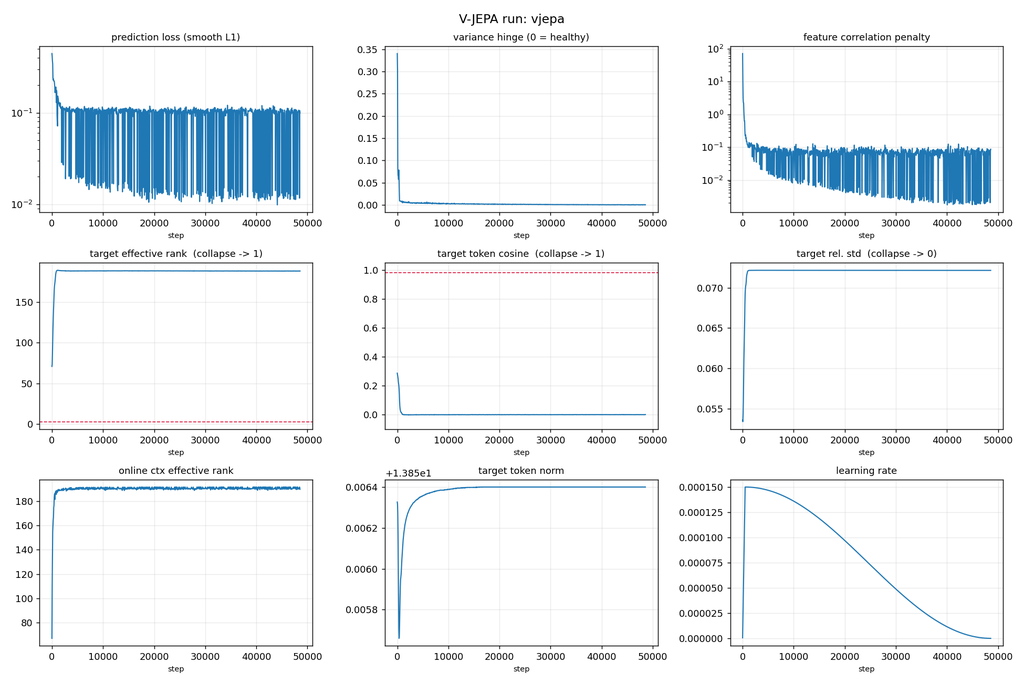

Every diagnostic over the full 40-epoch run.

## 5.2 The linear probe

Frozen encoder, ridge regression to ball (y, x), **split by episode** so train and test never share a trajectory:

| encoder | R^2 | MAE (y / x) px |
| --- | --- | --- |
| raw downsampled pixels | 0.937 | 0.95 / 1.40 |
| **V-JEPA (EMA target)** | **0.882** | **0.94 / 2.61** |
| randomly initialised ViT | 0.818 | 1.49 / 2.06 |
| constant predictor (= collapsed) | 0.000 | 7.16 / 12.74 |

Read this carefully, in the spirit of 4.4:

- **The representation is definitively not collapsed.** A collapsed encoder is pinned to 0.000 and cannot move off it. 0.882 is nowhere near that.
- **The margin over random init is real but modest** (+0.064 R^2, and a clear win on `y`: 0.94 px vs 1.49 px). It is not the dramatic separation you might hope for, and I would not lead a paper with it. Section 4.4 explains why: a random ViT is nearly an information-preserving projection, and reading a bright ball out of a 64x64 frame is an easy task that does not discriminate.
- Raw pixels beating both is expected and healthy — the ball is *literally visible*, so pixels are close to an upper bound for this particular readout.

To actually separate V-JEPA from random init you need the harder probes in 6.6.

## 5.3 The masking, on real frames

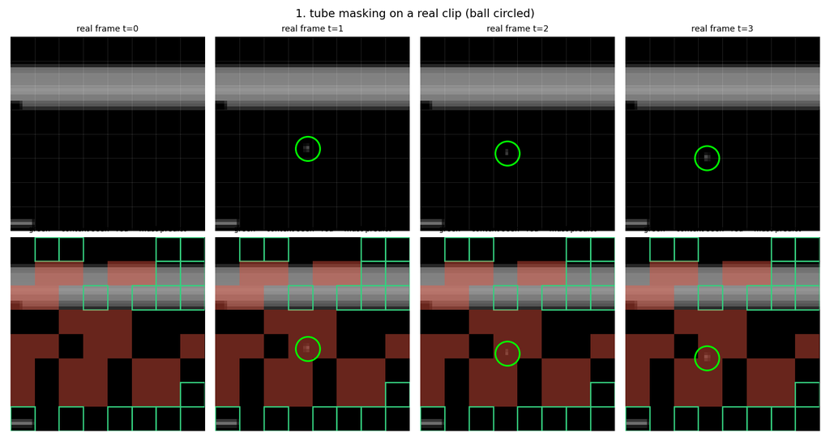

## 5.4 The collapse verdict

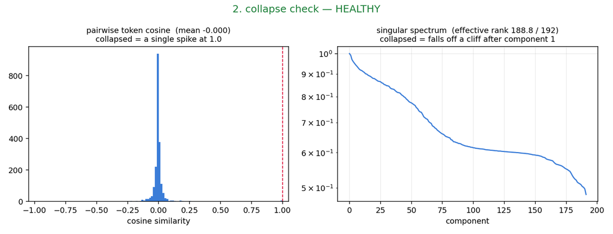

Pairwise token cosine **+0.000**, effective rank **188.8**. A collapsed model puts all cosine mass in a spike at 1.0 and all spectral mass in the first component; this does neither.

## 5.5 What the encoder represents

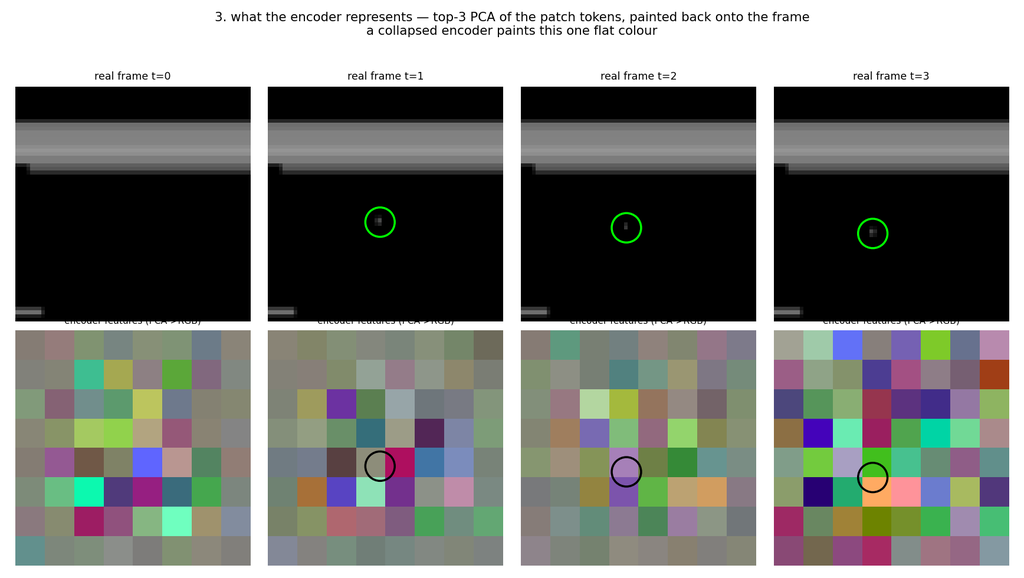

Top-3 PCA of the patch tokens, painted back onto the frame as RGB.

**An honest correction.** Before I generated this I predicted you would see bricks, playfield and paddle come out as clean, distinct colour regions. You do not. What you actually see is high per-patch colour variety with only loose spatial structure, and noticeably more saturation in later frames.

What this figure does establish is the negative result, which is the one it was built for: the representation is **not** flat, so it is not collapsed. What it does not establish is clean semantic segmentation. That is consistent with 5.2 — this encoder is healthy and informative, but it has not learned a dramatically more structured representation than its initialisation. On a 64x64 grayscale game with 21 never-changing patches and a random-policy dataset, that is roughly what you should expect. See 6.2(e).

## 5.6 Where the predictor is right and wrong

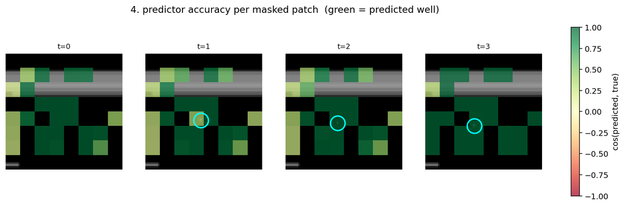

Mean cosine between predicted and true target embeddings over masked patches: **+0.802**.

## 5.7 The ball

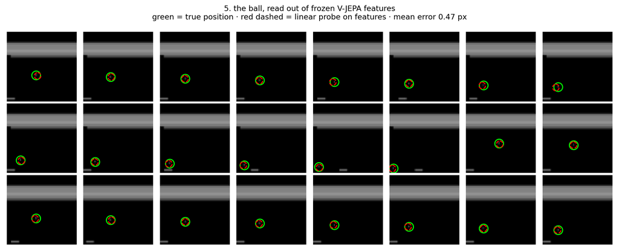

Green is the true position, red is a **linear** readout of the frozen features. Mean error **0.47 px** on this stretch. The red circle sits inside the green one in nearly every panel.

## 5.8 The world model — and a measurement error worth learning from

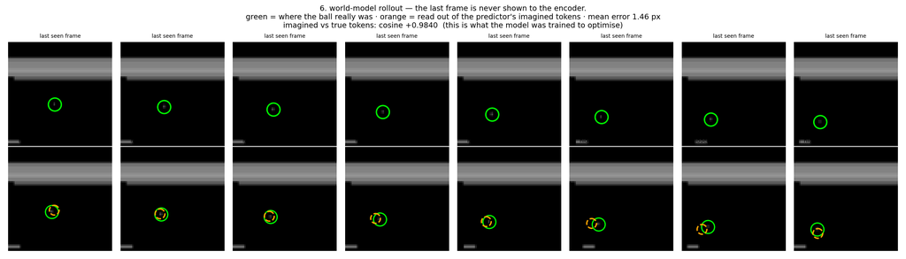

The last frame is **never shown to the encoder**. The predictor imagines its 64 tokens from the previous three, and a linear probe reads a ball position out of those imagined tokens.

**Imagined vs. true token cosine: +0.9840.** For scale, predicting the mean token instead scores +0.079. The predictor is genuinely reconstructing the representation of a frame it has never seen.

There is a methodological trap here that I fell into first, and it is worth recording. My initial version fitted the probe on **real** encodings and applied it to **imagined** ones. That reported a ball error of **27.95 px** — worse than a constant predictor — and it would have been easy to write up as “the world model does not work”.

It was not the model. The predictor is 98.4% cosine-accurate and its output norms match the truth to within 1.3%. But a ridge map over 12,288 features has large weights, and it amplifies that last 1.6% of residual into tens of pixels. The probe was being evaluated outside the distribution it was fitted on.

Fitting the readout **in the space it is actually applied in** — on imagined tokens — gives:

| readout | R^2 | MAE (y / x) px |
| --- | --- | --- |
| probe fitted on real features, applied to imagined | — | **27.95** (invalid) |
| **probe fitted on imagined tokens** | **0.795** | **2.67 / 4.61** |

The general lesson: **a probe measures the pair (representation, readout), never the representation alone.** If you change the space, refit the readout. The cosine number is the more trustworthy statistic precisely because it needs no fitted readout at all — it measures the thing the model was trained to optimise.

## 5.9 Regenerating

```bash
python -m eval.probe --ckpt runs/vjepa/checkpoint/final.pt
python visualize.py  --ckpt runs/vjepa/checkpoint/final.pt
python -m utils.plot_run runs/vjepa
```

# Part VI — Where this goes next

## 6.1 Adding actions — the single highest-value change

Right now the predictor is asked an impossible question: *where will the ball be next?* — when the answer depends on where the paddle moves, which depends on an action the model has never been told about.

You already save actions in `data/collect.py`. They are sitting unused in `rollouts/*.npz`.

**The change is small.** Condition the predictor on the action sequence:

```python
class Predictor(nn.Module):
    def __init__(self, ..., n_actions=4):
        self.act_embed = nn.Embedding(n_actions, d_pred)

    def forward(self, x, ctx_idx, tgt_idx, actions):
        # actions: (B, T-1) -> one token per transition
        a = self.act_embed(actions)                    # (B, T-1, d_pred)
        H = torch.cat([ctx, a, M], dim=1)
        ...
        return H[:, ctx.shape[1] + a.shape[1]:, :]
```

Three tokens added to a 160-token sequence. That is the whole change, plus plumbing actions through `ClipDataset` (you would save `actions.npy` alongside `frames.npy` in `preprocess.py`).

**Why it is worth doing first:**

- It removes the dominant source of irreducible uncertainty. The causal-mask loss should drop measurably, and that drop is a *real* measurement, not a collapse artefact.
- It converts the model from a passive video model into an actual **world model**: `s_{t+1} = f(s_t, a_t)`. That is the object you need for planning.
- It gives you a much sharper evaluation: **action-conditioned probe accuracy**. Does knowing the action improve next-ball prediction? If yes, the model has learned that actions have consequences — something a random encoder provably cannot do, which closes the gap identified in 4.4.
- It is exactly what **V-JEPA 2-AC** does on top of V-JEPA 2.

This is a weekend of work and it is the experiment that makes the project publishable rather than a reproduction.

## 6.2 Getting finer features

Your ball is roughly 1-2 pixels at 64x64 and it lives inside an 8x8 patch that is otherwise black. There is a real risk the encoder treats it as noise.

Ordered by value-per-effort:

**a. Smaller patches.** `patch_size=4` at 64x64 gives a 16x16 grid, 256 spatial cells, 1024 tokens per clip. Attention cost goes up 16x — at your model size that is affordable and it is the most direct fix for “the ball is smaller than a patch”.

**b. Higher resolution.** 96x96 or 128x128 with `patch_size=8`. Same token count as (a) at 128x128, but the ball is genuinely bigger rather than just more finely diced. Costs preprocessing time and disk.

**c. Longer clips.** `T=8` or `T=16`. Velocity is only weakly observable from 4 frames at frameskip 4; acceleration and bounce dynamics need more. This is probably the highest-value change after actions, and it is nearly free — change `T` in `ClipDataset` and `n_frames` in the ViT.

**d. Factorised or rotary positional embeddings.** Right now one learned `(1, 256, 192)` table encodes space and time jointly, so the model must learn “same cell, one frame later” separately for all 64 cells. Separate `pos_space` and `pos_time` embeddings that add — or RoPE over time — give that relation for free and generalise to clip lengths not seen in training.

**e. Better data.** This is the big one, and it is not an architecture change. A uniformly random policy almost never breaks bricks or sustains a rally. Collect with an epsilon-greedy DQN, or even a scripted “track the ball” paddle controller, and the dataset suddenly contains the dynamics you want the model to learn. **Your data currently has 21 of 64 patches that literally never change.** No architecture fixes that.

**f. Multi-mask targets per step.** V-JEPA computes several target blocks per forward pass and averages, which is a substantial effective-batch increase for almost no extra compute (the expensive target-encoder forward is shared). Easy win.

## 6.3 Planning: turning the world model into a controller

Once 6.1 is done you have `s_{t+1} = f(s_t, a_t)` in latent space, and you can plan without ever rendering a frame:

1. encode the current clip to `s_t`
2. sample N action sequences
3. roll each forward through the predictor — **latent only, no decoder**
4. score the resulting latents with some objective
5. take the first action of the best sequence, re-plan next step (MPC / CEM)

The scoring function is the open question and it is where the interesting research is. Options: distance to a goal latent (this is what **DINO-WM** and **PLDM** do), a learned reward head, or an intrinsic objective. Your `WM+ICM(Lunar-Lander)` project is directly relevant here.

The attraction is that planning in a 192-d latent space is cheap, and the model never has to commit to pixels it cannot know.

## 6.4 The latent world-model landscape

You asked about “LeWM”. I want to be careful: I am not confident which specific work you mean, and I would rather flag that than invent a citation. The plausible readings, and what each contributes:

- **LWM (Large World Model)** — long-context video+language modelling with ring attention. Relevant for scale and long horizons, less so for control.
- **“LeCun world model”** — the H-JEPA architecture from *A Path Towards Autonomous Machine Intelligence* (2022): a hierarchy of JEPAs at increasing levels of abstraction and longer time horizons, with a configurator and a cost module. This is the programmatic vision your repo is one rung of.
- **A latent world model generally** — the family below.

If you tell me which you meant I will write that section properly.

The systems worth knowing in this space:

| system | representation | dynamics learned by | plans by |
| --- | --- | --- | --- |
| **Dreamer V3** | RSSM latent, **pixel decoder** | reconstruction + KL | actor-critic in imagination |
| **TD-MPC2** | latent, **no decoder** | reward/value consistency | MPC + learned value |
| **MuZero** | latent, no decoder | reward/value/policy match | MCTS |
| **DINO-WM** | **frozen** DINOv2 features | latent dynamics only | MPC to a goal latent |
| **V-JEPA 2-AC** | V-JEPA features | action-conditioned latent prediction | MPC to a goal latent |
| **this repo** | V-JEPA features | latent prediction, no actions yet | — |

The trend is clear and it is the trend your paper is about: **the decoder is being removed.** Dreamer needs one, TD-MPC2 and MuZero dropped it in favour of task signal, and the JEPA line drops it in favour of self-supervised latent prediction.

## 6.5 Dreamer x JEPA — your branch point

This is where your own paper thesis lives, so let me state the trade cleanly.

**What Dreamer has that you do not:**

- a **stochastic latent** (categorical in V2/V3) with a KL term, so it represents a *distribution* over next states rather than a point. That is the principled answer to multimodality: don’t average the modes, model them.
- a **recurrent state** (the RSSM deterministic path) carrying arbitrarily long history, versus your fixed 4-frame window.
- **reward and continuation heads**, so the latent is shaped by what matters for control, not only by what is predictable.
- a complete **actor-critic trained in imagination** — it is an agent, not just a representation.

**What you have that Dreamer does not:**

- **no reconstruction loss.** Dreamer’s decoder forces the latent to retain every pixel, including all 21 of your never-changing patches. That is capacity spent on nothing, and it is the mode-averaging problem in 1.2 baked into the objective.
- **no reward requirement.** You can pretrain on unlimited unlabelled video. Dreamer needs an environment and a reward signal.
- **a representation that is free to be abstract.**

**The synthesis, and the actual research question:** replace Dreamer’s reconstruct-the-pixels objective with a JEPA latent-prediction objective, and keep the stochastic recurrent latent, the reward head, and the actor-critic.

The hard part — and this *is* the contribution, not a detail — is that removing the decoder removes Dreamer’s collapse prevention. Reconstruction is what guarantees Dreamer’s latent stays informative. Take it away and you inherit every problem in Part III of this document, in an RL setting where the data distribution is also shifting under you. Everything you built here — the target normalisation, the variance/covariance guard rails, the cosine diagnostic, the tripwire — is exactly the machinery that problem needs.

Your Jensen-gap framing is the theoretical half. **This repo is the empirical half**: it is a working demonstration that latent prediction collapses in five specific, nameable, fixable ways, with measurements for each.

## 6.6 A concrete ladder

Each rung is a real experiment with a measurable outcome. In order:

1. **Actions in the predictor** (6.1). Metric: causal-mask loss, and action-conditioned probe R^2 vs unconditioned. *This is the one to do next.*
2. **Longer clips**, `T=8`. Metric: multi-step ball prediction error.
3. **Better data** — epsilon-greedy or scripted policy. Metric: fraction of patches with non-zero temporal variance; probe R^2 on held-out episodes.
4. **A harder probe** — predict the ball 4 steps ahead, or with only 200 probe samples. Metric: V-JEPA vs random-init. *This is what closes the gap in 4.4.*
5. **Latent MPC** (6.3). Metric: episode return vs a random policy.
6. **Dreamer-JEPA ablation** (6.5). Metric: collapse with/without the guard rails; return vs stock Dreamer V3.

# Appendix A — file reference

| file | what it does |
| --- | --- |
| `data/collect.py` | 300 random Breakout episodes -> `rollouts/*.npz` |
| `data/preprocess.py` | crop, resize to 64x64, motion, `meta.json` |
| `data/ball_labels.py` | exact ball (y, x) per frame -> `proc/ball.npy` |
| `data/dataset.py` | `ClipDataset`: 4-frame clips, no life-loss seams |
| `data/check.py` | integrity checks on `proc/` |
| `data/inspect.py` | compares resize modes; where the crop was derived |
| `models/vit.py` | space-time ViT encoder |
| `models/layers.py` | attention (SDPA), MLP, SwiGLU, norms |
| `models/masking.py` | multi-block tube masks + causal mask |
| `models/predictor.py` | narrow predictor |
| `models/ema.py` | EMA target + momentum schedule |
| `models/check_order.py` | verifies frame-major token ordering |
| `train/loss.py` | target norm + smooth-L1 + VICReg |
| `train/vjepa.py` | training loop, param groups, tripwire |
| `utils/monitor.py` | collapse diagnostics |
| `utils/logger.py` | `metrics.csv` per run |
| `utils/watch.py` | live health view |
| `utils/plot_run.py` | `curves.png` |
| `eval/probe.py` | ridge probe: features -> ball position |
| `visualize.py` | the six figures in Part V |
| `docs/make_figures.py` | the diagrams in this document |

# Appendix B — commands

```bash
# one-time
python -m data.collect
python -m data.preprocess
python -m data.ball_labels
python -m data.check

# train
python -m train.vjepa --run runs/vjepa --epochs 40
PYTHONPATH=. python -m utils.watch          # live health, separate terminal

# evaluate
python -m eval.probe --ckpt runs/vjepa/checkpoint/final.pt
python visualize.py  --ckpt runs/vjepa/checkpoint/final.pt
python -m utils.plot_run runs/vjepa

# rebuild this document
python -m docs.make_figures && bash docs/build_pdf.sh
```

# Appendix C — glossary

**JEPA** — Joint-Embedding Predictive Architecture. Predict the representation of a hidden part from a visible part.

**Collapse** — the encoder maps all inputs to the same output. Global minimum of the naive objective; destroys all information.

**EMA target** — exponential moving average copy of the encoder, used as the prediction target, never receives gradient.

**Tube masking** — masking a spatial cell in every frame, so temporal copying cannot solve the task.

**Effective rank** — `exp(entropy of the normalised singular value spectrum)`. Beware the centred version; it stays high through collapse.

**Token cosine** — mean cosine similarity between distinct tokens. The reliable collapse detector: healthy near 0, collapsed near 1.

**Linear probe** — a linear map from frozen features to a known quantity. Measures whether information is present *and easy to use*.

**Jensen gap** — for convex `L`, `L(E[y]) <= E[L(y)]`; why an L2 objective under uncertainty produces the blurred mean rather than a sample.

**RSSM** — Recurrent State-Space Model, the latent used by PlaNet and Dreamer.